# INFSCI 2595 Final

Part iA: Predictors (Lexicon: AFINN)

Ben Stein

4/27/2022

# About this document

In this document, I perform exploratory data analysis on the variables from the AFINN lexicon data.

# Setup

## Libraries and tools

```r
library(tidyverse)
source("./tools.R")
```

## Data

```r
df <- load_project_data() %>%
  select(response_log, outcome_numeric, starts_with("xa"))
df %>% glimpse
```

```
## Rows: 677
## Columns: 10
## $ response_log    <dbl> 0.9624073, 0.1694321, 0.7959862, 1.0030975, 0.3942847,~
## $ outcome_numeric <dbl> 0, 0, 1, 0, 0, 0, 0, 0, 0, 0, 0, 0, 0, 0, 0, 0, 0, 1, ~
## $ xa_01           <dbl> 12.000000, 3.000000, 9.000000, 7.080000, 6.451613, 6.8~
## $ xa_02           <dbl> 12, 3, 9, 29, 17, 18, 24, 27, 20, 19, 15, 24, 24, 15, ~
## $ xa_03           <dbl> 12, 3, 9, -7, -2, 2, -9, -5, -3, -3, -1, 1, -2, -3, 3,~
## $ xa_04           <dbl> 6.000000, 3.000000, 6.750000, 2.425333, 3.023656, 2.68~
## $ xa_05           <dbl> 6.0000000, 3.0000000, 4.5000000, -3.5000000, -0.666666~
## $ xa_06           <dbl> 6.000000, 3.000000, 9.000000, 9.000000, 13.000000, 6.0~
## $ xa_07           <dbl> 9.000000, 3.000000, 7.500000, 4.466667, 4.612903, 4.07~
## $ xa_08           <dbl> 3.0000000, 3.0000000, 6.0000000, 0.7066667, 1.3225806,~
```

# Distributions

Let’s look at the distributions of the variables first.

```r
df %>%
  select(starts_with("xa")) %>%
  summary
```

```
##      xa_01            xa_02           xa_03            xa_04
##  Min.   :-3.000   Min.   :-3.00   Min.   :-9.000   Min.   :-2.000
##  1st Qu.: 6.000   1st Qu.: 8.00   1st Qu.: 0.000   1st Qu.: 2.252
##  Median : 8.000   Median :13.00   Median : 3.000   Median : 2.925
##  Mean   : 8.073   Mean   :13.24   Mean   : 3.836   Mean   : 2.945
##  3rd Qu.: 9.750   3rd Qu.:18.00   3rd Qu.: 7.000   3rd Qu.: 3.500
##  Max.   :35.000   Max.   :38.00   Max.   :35.000   Max.   :12.000
##      xa_05            xa_06            xa_07            xa_08
##  Min.   :-8.000   Min.   :-2.000   Min.   :-2.000   Min.   :-5.000
##  1st Qu.: 0.000   1st Qu.: 3.000   1st Qu.: 3.882   1st Qu.: 0.400
##  Median : 1.333   Median : 4.333   Median : 4.613   Median : 1.140
##  Mean   : 1.380   Mean   : 5.149   Mean   : 4.699   Mean   : 1.221
##  3rd Qu.: 2.667   3rd Qu.: 6.500   3rd Qu.: 5.400   3rd Qu.: 2.000
##  Max.   :12.000   Max.   :23.000   Max.   :13.000   Max.   :12.000
```

Note the differing scales of the variables - we’ll probably want to center and scale for most models.

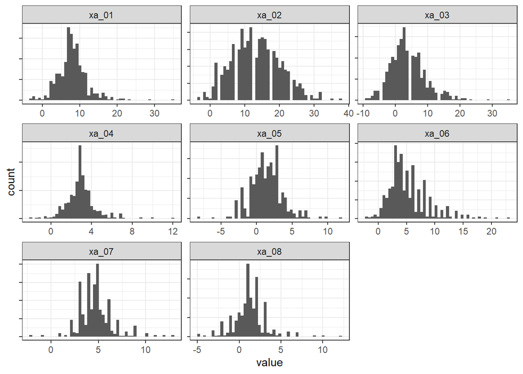

```r
visualize_distributions(df, "xa")
```

While all variables are loosely Gaussian, some are more Gaussian than others (e.g. `xa_02` through `xa_05`).

## Distinct values

As I worked with each group of continuous predictors, I noticed that some seem to have more unique values than others. Let’s quantify that:

```r
df %>%
  select(starts_with("xa")) %>%
  pivot_longer(cols = everything()) %>%
  group_by(name) %>%
  unique %>%
  count
```

```
## # A tibble: 8 x 2
## # Groups:   name [8]
##   name      n
##   <chr> <int>
## 1 xa_01   257
## 2 xa_02    38
## 3 xa_03    35
## 4 xa_04   411
## 5 xa_05    87
## 6 xa_06    87
## 7 xa_07   213
## 8 xa_08   212
```

As we can see here, inputs 1, 4, 7, and 8 have significantly more unique values than the others.

# Correlation within the group

Let’s see if any of these inputs are correlated with one another.

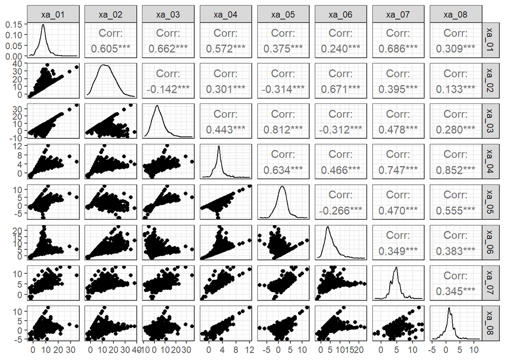

```r
visualize_correlations(df, "xa")
```

There seem to be significant correlations between some of the variables within the group. We’ll keep that in mind when selecting variables for modeling.

There is at least moderate correlation among several variables.

# In relation to the continuous `response` variable

Note that I log-transformed response since that’s what I’ll be predicting anyway.

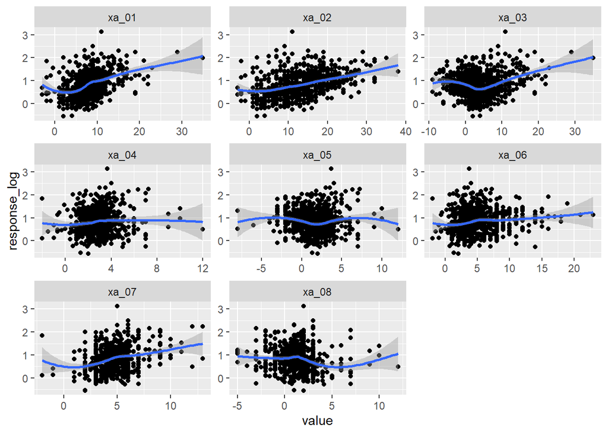

```r
df %>%
  pivot_longer(cols = starts_with("xa")) %>%
  ggplot(mapping = aes(x = value, y = response_log)) +
  geom_point() +
  geom_smooth(formula = y ~ x, method = "loess") +
  facet_wrap(~ name, scales = "free")
```

# In relation to the `outcome` classification target

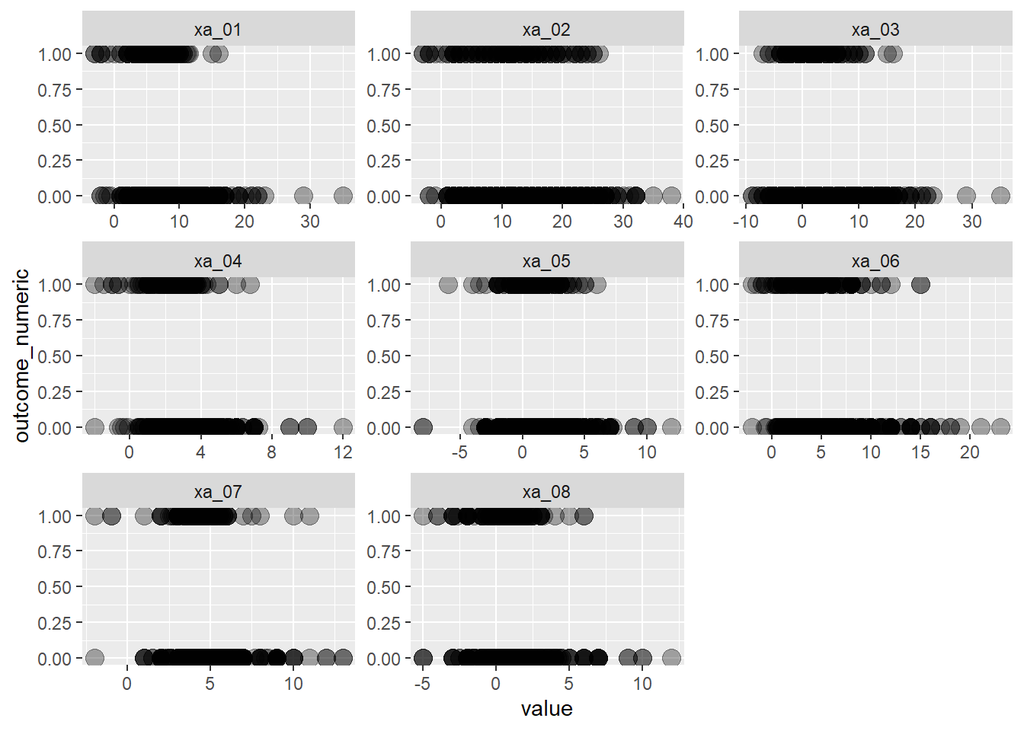

```r
df %>%
  select(-response_log) %>%
  pivot_longer(cols = starts_with("xa")) %>%
  ggplot(mapping = aes(x = value, y = outcome_numeric)) +
  geom_point(size = 4, alpha = .33) +
  facet_wrap(~ name, scales = "free")
```

It’s unclear how this group of predictors relates to `outcome`. High values of the predictors seem to result in more nonevents than events, but it’s not clear what happens at middle and low values.